# Dynamic/Reproducible Report

Ming Li, Amazon  
[Hui Lin](http://scientistcafe.com), DuPont

July 30, 2017 @ JSM2017

# I know you click, click, copy and paste

[figure not shown]

# But imagine you hear these words after you finished a project

**Please do that again!** (sorry we made a mistake in the data, want to change a parameter, and yada yada)

[figure not shown]

# R Markdown

- Example: EX1_Markdown.Rmd([output](http://scientistcafe.com/CE_JSM2017/Examples/EX1_Markdown.html))
- Markdown: lightweight markup language designed to make authoring content easy for everyone
- R + Markdown = R Markdown
- How It Works?

# Get Started

- Create a sample `.Rmd` file in R Studio:

[figure not shown]

# Get Started

- Input your document title and author name and click “OK”:

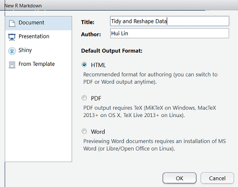

# Markdown Basic - Paragraphs, Headers

```
# H1
## H2
### H3
#### H4
##### H5
###### H6

Alternatively, for H1 and H2, an underline-ish style:

A First Level Header
=====================

A Second Level Header
---------------------
```

# Markdown Basic - Paragraphs, Headers

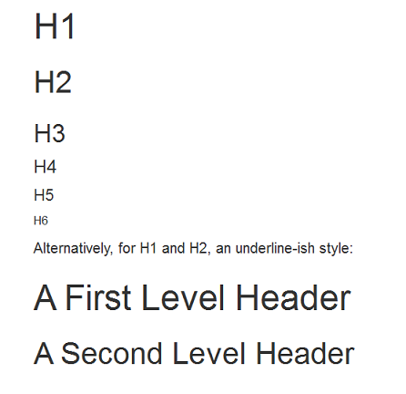

# Markdown Basic - Blockquotes

```
A statistician gave birth to twins, but only had one of them baptised.
She kept the other as a control.

> All you need in this life is ignorance and confidence,
and then success is sure. [Mark Twain]
```

Output:

A statistician gave birth to twins, but only had one of them baptised. She kept the other as a control.

> All you need in this life is ignorance and confidence, and then success is sure. [Mark Twain]

# Markdown Basic - Phrase Emphasis

```
Some of these words *are italic*.
Some of these words _are italic also_.

Use two asterisks for **bold**.
Or, if you prefer, __use two underscores instead__.

Strikethrough uses two tildes. ~~Scratch this.~~
```

Output:

Some of these words *are italic*. Some of these words *are italic also*.

Use two asterisks for **bold**. Or, if you prefer, **use two underscores instead**.

Strikethrough uses two tildes. Scratch this.

# Markdown Basic - Lists

```
* If it’s green and wiggles, it’s biology.
* If it stinks, it’s chemistry.
* If it doesn’t work, it’s Physics.
```

Output:

- If it’s green and wiggles, it’s biology.
- If it stinks, it’s chemistry.
- If it doesn’t work, it’s Physics.

# Markdown Basic - Lists

```
+ Engineers think that equations approximate the real world.
+ Scientists think that the real world approximates equations.
+ Mathematicians don’t care.
```

Output:

- Engineers think that equations approximate the real world.
- Scientists think that the real world approximates equations.
- Mathematicians don’t care.

# Markdown Basic - Lists

```
- Engineers think that equations approximate the real world.
- Scientists think that the real world approximates equations.
- Mathematicians don’t care.
```

Output:

- Engineers think that equations approximate the real world.
- Scientists think that the real world approximates equations.
- Mathematicians don’t care.

# HTML

- Create

```
---
title: "Tidy and Reshape Data"
author: Hui Lin
date: May 11, 2017
output: html_document
---
```

# Table of Contents (TOC)

- Top

```
---
title: "Tidy and Reshape Data"
author: Hui Lin
date: May 11, 2017
output:
  html_document:
    toc: true
    toc_depth: 3
---
```

- Floating

```
---
title: "Tidy and Reshape Data"
author: Hui Lin
date: May 11, 2017
output:
  html_document:
    toc: true
    toc_depth: 3
    toc_float: true
---
```

- `collapsed` (defaults to `TRUE`)
- `smooth_scroll` (defaults to `TRUE`)

# Code Chunks

- start with `` ```{r} `` and end with `` ``` ``
- keyboard shortcut Ctrl + Alt + I (OS X: Cmd + Option + I)
- Add Chunk command in the editor toolbar

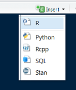

# Customize Chunks

- `include = FALSE` prevents code and results from appearing in the finished file. R Markdown still runs the code in the chunk, and the results can be used by other chunks.
- `echo = FALSE` prevents code, but not the results from appearing in the finished file. This is a useful way to embed figures.
- `message = FALSE` prevents messages that are generated by code from appearing in the finished file.
- `warning = FALSE` prevents warnings that are generated by code from appearing in the finished.
- `fig.height`, `fig.width` The width and height to use in R for plots created by the chunk (in inches).

# Inline Code

- Output:

```
The current time is 2017-07-29 15:44:58
```

# Global Options

- Treat each option that you pass to `knitr::opts_chunk$set` as a global default
- Prevent code for all chunks unless you overwrite in individual chunk header

# Example

- EX1_Markdown.Rmd([output](http://scientistcafe.com/CE_JSM2017/Examples/EX1_Markdown.html))

# HTML5 Slides

- `ioslides_presentation` - HTML presentations with ioslides
- `slidy_presentation` - HTML presentations with slidy
- `revealjs::revealjs_presentation` - HTML presentations with reveal.js

# `ioslides` presentation

- specify the `ioslides_presentation` output format
- Ex_ioslide.Rmd([output](http://scientistcafe.com/CE_JSM2017/Examples/Ex_ioslide.html))
- add a subtitle to a slide or section by including text after the pipe (|)

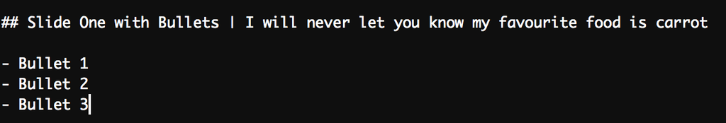

# Display modes

- ‘f’: fullscreen mode
- ‘w’: toggle widescreen mode
- ‘o’: overview mode
- ‘h’: code highlight mode

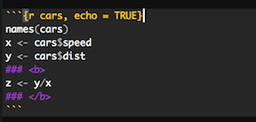

- ‘p’: show presenter notes

# `slidy` presentation

- specify the `slidy_presentation` output format
- Ex_slidy.Rmd([output](http://scientistcafe.com/CE_JSM2017/Examples/Ex_slidy.html))

# Display modes

- `C` Show table of contents
- `F` Toggles the display of the footer
- `A` Toggles display of current vs. all slides (useful for printing handouts)
- `S` Make fonts smaller
- `B` Make fonts larger

# Dashboards

- Reproducible, flexible
- Nice display: browser and mobile devices
- Support a wide variety of components
- Extensive support for text annotations
- Storyboard layouts for presenting sequences of visualizations and related commentary
- Deployed on any web server or attached to an email message
- Can be combined with Shiny

# Create a dashboard

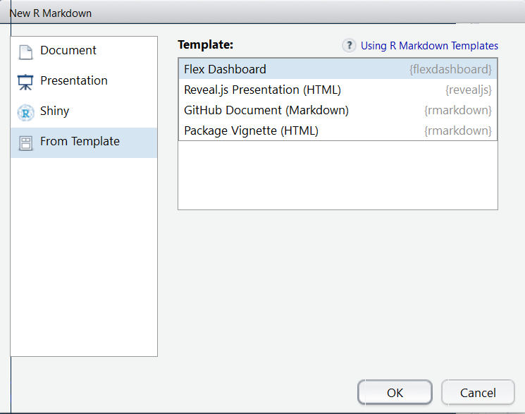

# Layout by Column

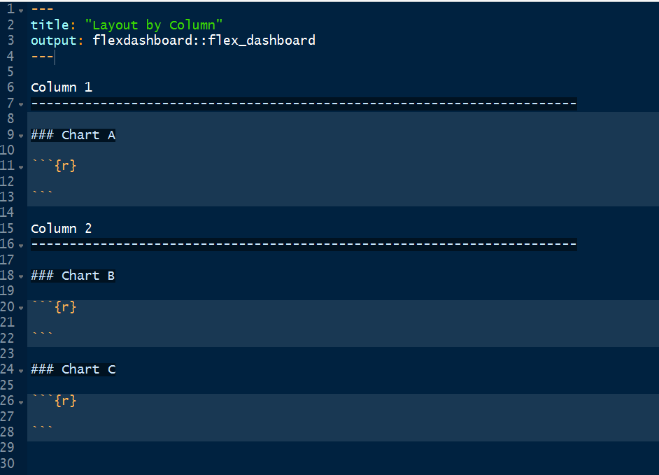

# Layout by Column Output

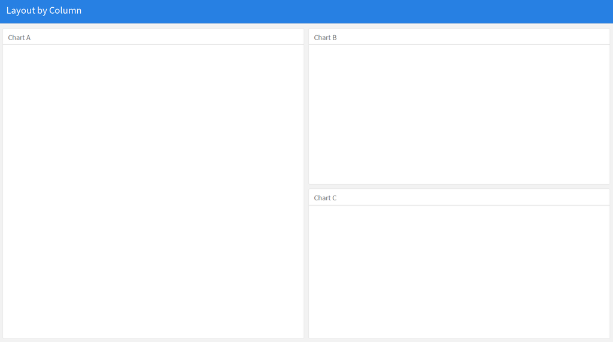

# Your Turn

- Create a dashboard with layout by column

# Layout by Row

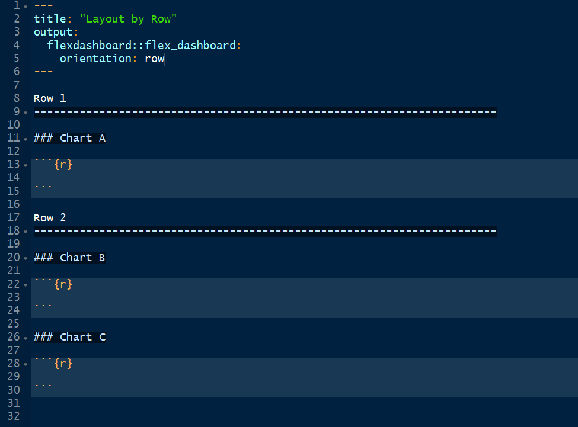

# Layout by Row Output

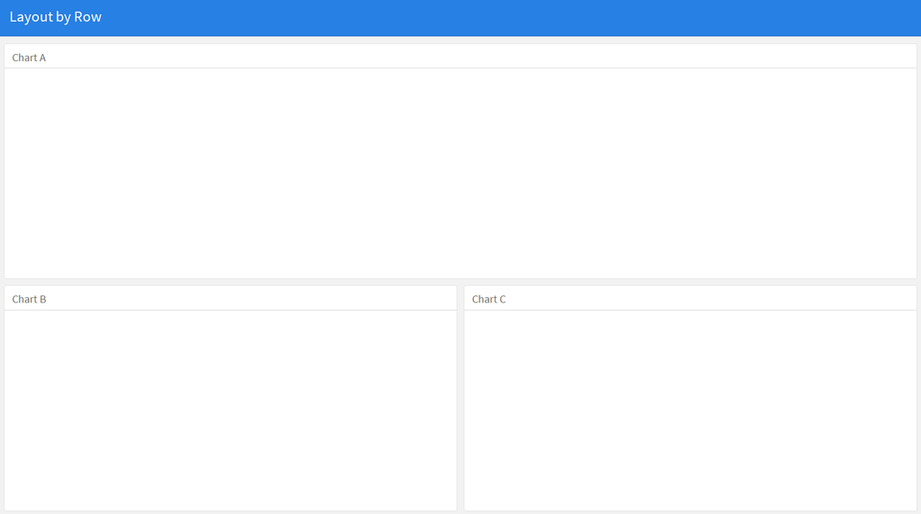

# Your Turn

- Create a dashboard with layout by row

# Multiple pages

```
Page 1
=====================================

Column 1 {data-width=600}
-------------------------------------

### Chart 1

Column 2 {data-width=400}
-------------------------------------

### Chart 2

Page 2 {data-orientation=rows}
=====================================

Row 1 {data-height=600}
-------------------------------------

### Chart 1

Row 1 {data-height=600}
-------------------------------------
```

# Your Turn

- [Dashboard](http://scientistcafe.com/CE_JSM2017/Examples/dashboard_multi-page.html) and [Source Code](https://raw.githubusercontent.com/happyrabbit/linhui.org/gh-pages/CE_JSM2017/Examples/dashboard_multi-page.Rmd)

# Storyboard

- Present a sequence of charts and related commentary

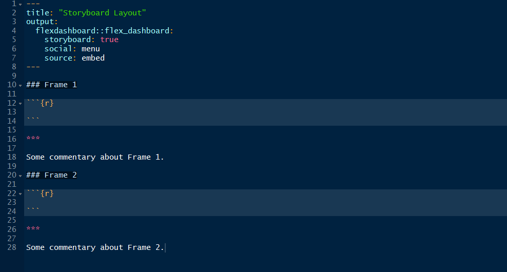

# Storyboard Output

- [See an example here](http://scientistcafe.com/CE_JSM2017/Examples/storyboard.html)

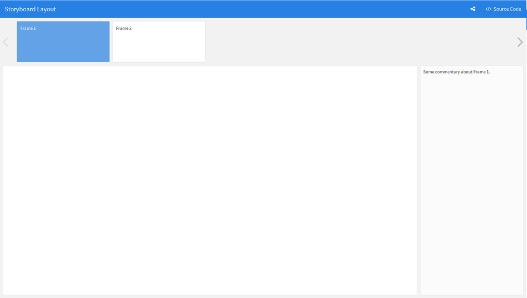

# Your Turn

- [Repeat the example here](http://scientistcafe.com/CE_JSM2017/Examples/storyboard.html)

# Components

- HTML Widgets: [Widgets List](http://scientistcafe.com/CE_JSM2017/dynamicreproducible-report.html#html-widgets-1)
- Standard R graphics: [source code](http://scientistcafe.com/CE_JSM2017/Examples/basicgraphic.Rmd), [output](http://scientistcafe.com/CE_JSM2017/Examples/basicgraphic.html)
- Tabular Data: [source code](http://scientistcafe.com/CE_JSM2017/Examples/tabularcom.Rmd), [output](http://scientistcafe.com/CE_JSM2017/Examples/tabularcom.html)
- Value Boxes: [source code](http://scientistcafe.com/CE_JSM2017/Examples/valuebox.Rmd) , [output](http://scientistcafe.com/CE_JSM2017/Examples/valuebox.html)
- Gauges: [source code](http://scientistcafe.com/CE_JSM2017/Examples/gauge.Rmd), [output](http://scientistcafe.com/CE_JSM2017/Examples/gauge.html)

# Shiny - Example 1

```r
library(shiny)
source("https://raw.githubusercontent.com/happyrabbit/linhui.org/gh-pages/CE_JSM2017/Examples/shiny1.R")
shinyApp(ui = ui, server = server)
```

**Example 1: Customer Segment Plot**

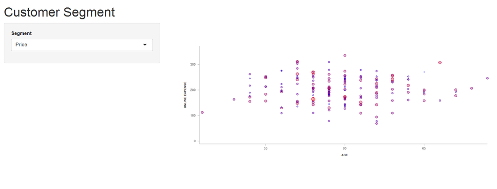

# Shiny: render calls

- `renderDataTable`
- `renderImage`
- `renderPlot`
- `renderPrint`
- `renderTable`
- `renderText`
- `renderUI`

# Shiny - Example 2

```r
library(shiny)
source("https://raw.githubusercontent.com/happyrabbit/linhui.org/gh-pages/CE_JSM2017/Examples/shiny2.R")
shinyApp(ui = ui, server = server)
```

**Example 2: Customer Segment Plot and Summary Table**

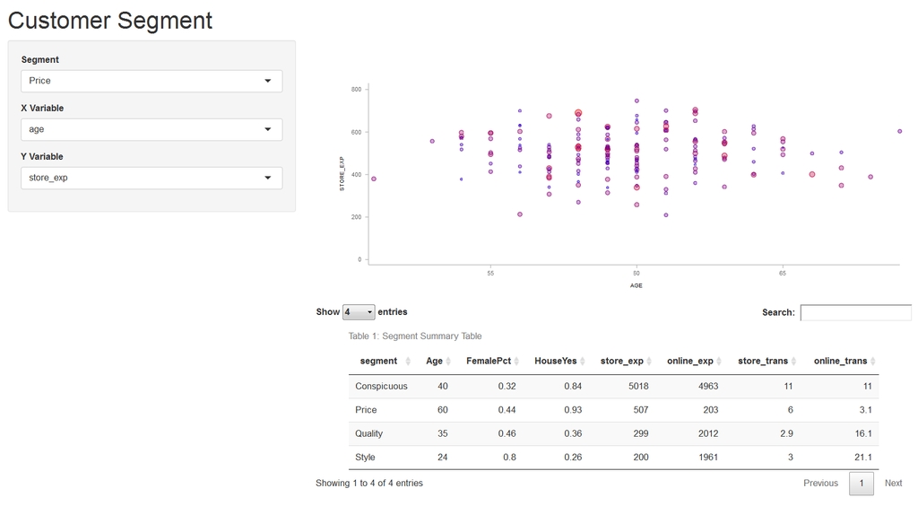

# `reactive()`

- A `reactive` expression to return the subset of data according to user’s choice
1. user provide input
2. backend R code will run using the input
3. report an output back to user
- see the [Reactivity Overview](http://shiny.rstudio.com/articles/reactivity-overview.html)

# Using `shiny` with `flexdashboard`

- Click [here](https://raw.githubusercontent.com/happyrabbit/linhui.org/gh-pages/CE_JSM2017/Examples/segmentdb.Rmd) to download the complete source code. Here is the [app](https://scientistcafe.shinyapps.io/shinysample/)

```
---
title: "Customer Segmentation Dashboard"
output:
  flexdashboard::flex_dashboard:
    orientation: rows
    vertical_layout: fill
    source_code: embed
    social: menu
    theme: flatly
runtime: shiny
---
```

# Some links

- Excellent [Shiny tutorial from beginning to deep level](http://shiny.rstudio.com/tutorial/)
- [Reactivity Overview](http://shiny.rstudio.com/articles/reactivity-overview.html)
- [Dashboard Appearance](http://rmarkdown.rstudio.com/flexdashboard/using.html#appearance)